# Resource Selection - First Example

[EFB 796: Techniques in Movement Ecology](https://eligurarie.github.io/MovementEcologyBook/EFB796/)

Elie Gurarie

October 2, 2025

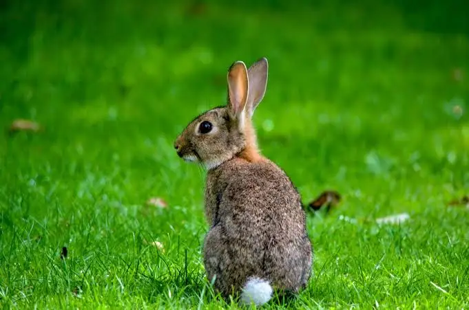

# Overview

This analysis demonstrates how to fit a Resource Selection Function (RSF). The dataset is one on New England Cottontail rabbits (*Sylvilagus transitionalis*), an elusive, rare species of cottontail rabbit endemic to the northeastern US. The data are available on Blackboard.

The steps are always fairly similar for fitting an RSF:

1. Loading and preparing spatial data (locations and habitat covariates)
2. Creating used and available point datasets
3. Fitting and comparing candidate models
4. Visualizing model predictions and interactions

# Load Packages

For raster data, `raster` is the classic, `terra` is the newcomer, but is missing some key functions

```r
# require(terra)
require(raster)
require(sf)
require(mapview)
```

Other packages we’ll introduce as needed, but we’ll try (as usual) to stick to as many base function as possible.

# Load Data

We’ll load the New England Cottontail location data and the associated habitat covariates for the cranberry bog study area.

```r
load("data/Cranberry_Data.rda")
```

This contains several objects:

```r
ls()
```

```
## [1] "Cranberry_covariates" "CranNEC"              "CranNEC_sf"
```

Let’s take a quick look at the spatial data:

```r
mapview(CranNEC_sf)
plot(Cranberry_covariates)
```

[output not shown]

## Cleaning up spatial data

Oops! Two of the layers are identical. We clean up the covariate rasters by removing an unnecessary layer and setting zeros to NA.

```r
Cranberry_covariates <- dropLayer(Cranberry_covariates, 3)
Cranberry_covariates[Cranberry_covariates == 0] <- NA
```

Now be sure to transform the cottontail location data to match the coordinate system of our rasters:

```r
CranNEC_sf <- CranNEC_sf |> st_transform(crs(Cranberry_covariates))
```

and confirm that the locations are correct:

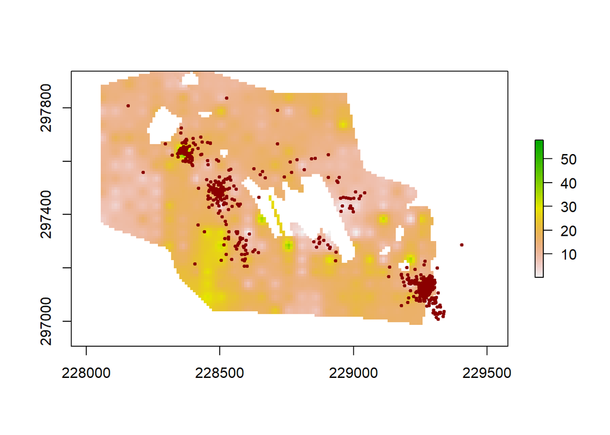

```r
plot(Cranberry_covariates[[1]])
plot(CranNEC_sf, add = TRUE, col = "darkred", pch = 19, cex = 0.5)
```

# Create “Used” Dataframe

To obtain covariate values at each cottontail location, we use the all-powerful and fast `extract()` function:

```r
covars <- extract(Cranberry_covariates, CranNEC_sf)
used_df <- data.frame(CranNEC_sf |> st_drop_geometry(),
                      st_coordinates(CranNEC_sf),
                      covars,
                      Used = TRUE)
```

# Create Available Dataset

## Define Availability Domain with MCP

We’ll define the available habitat using a Minimum Convex Polygon (MCP) around the observed locations.

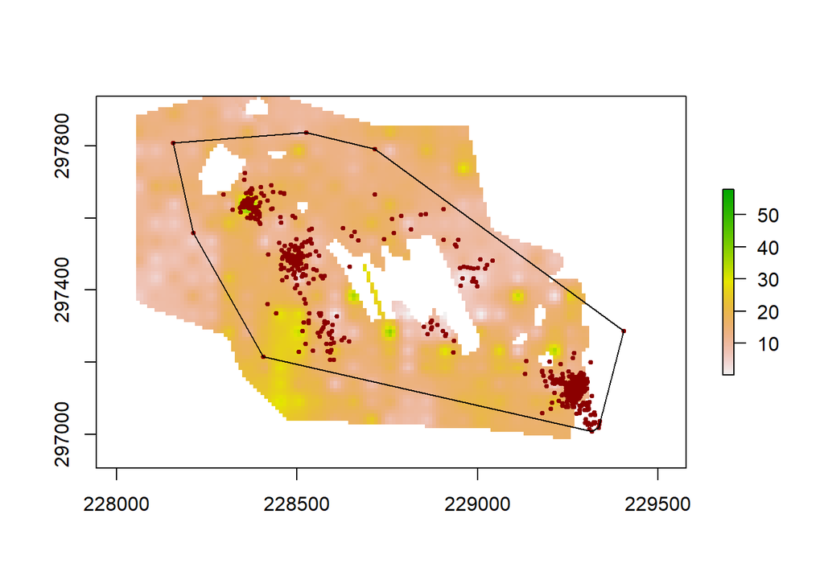

```r
xy <- st_coordinates(CranNEC_sf)
mcp <- xy[chull(xy),]
mcp <- rbind(mcp, mcp[1,])
mcp_sf <- st_polygon(list(mcp))

plot(Cranberry_covariates[[1]])
plot(CranNEC_sf, add = TRUE, col = "darkred", pch = 19, cex = 0.5)
plot(mcp_sf, add = TRUE)
```

We can also add a buffer around the MCP to expand the available area:

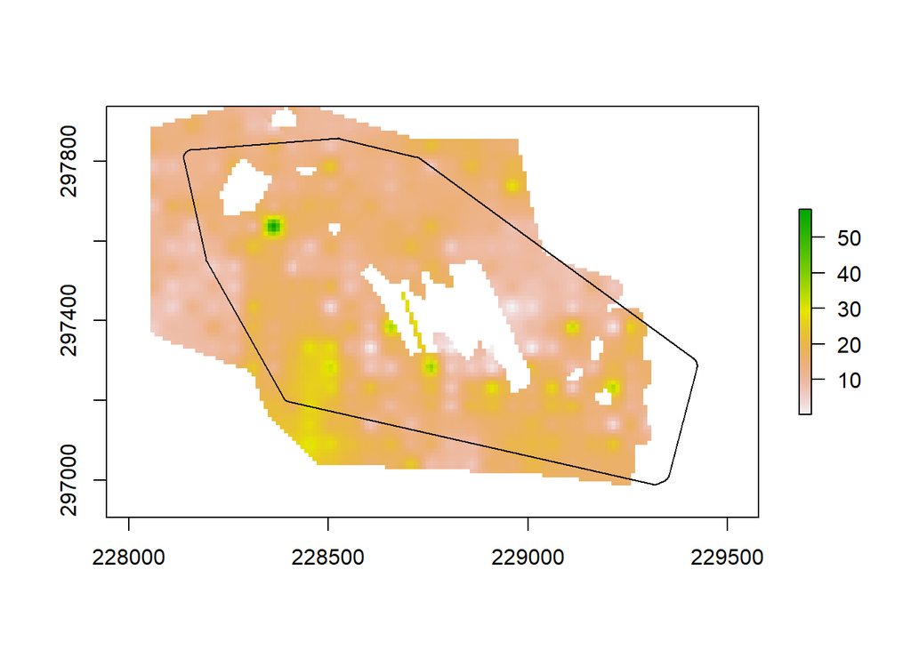

```r
mcp_buffered <- st_buffer(mcp_sf, 20)
plot(Cranberry_covariates[[1]])
plot(mcp_buffered, add = TRUE)
```

## Sample Available Points

We’ll sample pseudo-absence points from within the buffered MCP. A common approach is to use a 5:1 ratio of available to used points.

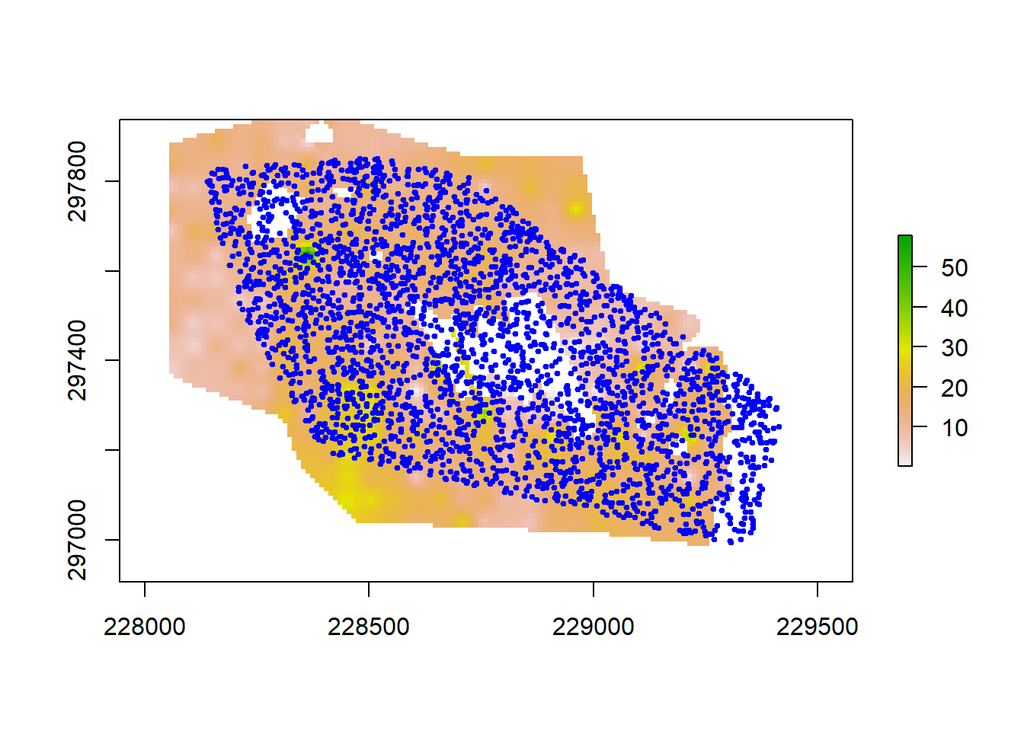

```r
n_used <- nrow(used_df)
n_available <- n_used * 5

available_pts <- st_sample(mcp_buffered, n_available)
plot(Cranberry_covariates[[1]])
plot(available_pts, add = TRUE, col = "blue", pch = 19, cex = 0.5)
```

Now extract covariate values at the available points:

```r
covars_available <- extract(Cranberry_covariates, st_coordinates(available_pts))
available_df <- data.frame(Used = FALSE,
                           st_coordinates(available_pts),
                           covars_available)
```

## Combine Used and Available Data

Comparing the two data frames, we need to fill in some empty gaps in the “available”

```r
head(used_df)
```

|  | EarTag | Date | Sex | Species | Loc_Type | Age | Location | X | Y | Canopy_cover | invasive_stem | Used |
| --- | --- | --- | --- | --- | --- | --- | --- | --- | --- | --- | --- | --- |
| 947 | 504 | 2013-12-20 | M | NEC | Homing | Adult | Cranberry Mountain SMUA | 228524.5 | 297836.8 | 10.34300 | 10.638911 | TRUE |
| 948 | 724 | 2016-07-12 | F | NEC | Homing | Adult | Cranberry Mountain SMUA | 228156.7 | 297808.4 | 11.80909 | 23.480612 | TRUE |
| 949 | 679 | 2015-10-28 | M | NEC | Triangulation | Adult | Cranberry Mountain SMUA | 228295.5 | 297665.4 | 16.49021 | 9.925657 | TRUE |
| 950 | 651 | 2015-07-16 | F | NEC | Triangulation | Juvenile or Sub-adult | Cranberry Mountain SMUA | 228352.5 | 297707.0 | 13.92546 | 13.922201 | TRUE |
| 951 | 679 | 2015-10-21 | M | NEC | Triangulation | Adult | Cranberry Mountain SMUA | 228353.2 | 297648.7 | 40.63403 | 8.716539 | TRUE |
| 952 | 586 | 2015-06-02 | F | NEC | Triangulation | Adult | Cranberry Mountain SMUA | 228354.0 | 297724.5 | 12.92257 | 12.796040 | TRUE |

```r
head(available_df)
```

| Used | X | Y | Canopy_cover | invasive_stem |
| --- | --- | --- | --- | --- |
| FALSE | 228361.4 | 297606.7 | 25.74304 | 11.448229 |
| FALSE | 229293.7 | 297340.6 | NA | NA |
| FALSE | 228713.4 | 297153.2 | 11.54692 | 6.873642 |
| FALSE | 228591.1 | 297183.6 | 16.64902 | 2.736128 |
| FALSE | 228563.8 | 297725.2 | 14.99659 | 10.409967 |
| FALSE | 228527.6 | 297176.4 | 19.63946 | 4.410995 |

THe handy `gtools` function `smartbind` does this well:

```r
require(gtools)
NEC_RSF_df <- smartbind(used_df, available_df)

# Remove rows with missing covariate data
NEC_RSF_df <- NEC_RSF_df |> subset(!is.na(Canopy_cover))
```

check out our complete dataset:

```r
dim(NEC_RSF_df)
```

```
## [1] 2961   12
```

```r
head(NEC_RSF_df)
```

|  | EarTag | Date | Sex | Species | Loc_Type | Age | Location | X | Y | Canopy_cover | invasive_stem | Used |
| --- | --- | --- | --- | --- | --- | --- | --- | --- | --- | --- | --- | --- |
| 1:1 | 504 | 2013-12-20 | M | NEC | Homing | Adult | Cranberry Mountain SMUA | 228524.5 | 297836.8 | 10.34300 | 10.638911 | TRUE |
| 1:2 | 724 | 2016-07-12 | F | NEC | Homing | Adult | Cranberry Mountain SMUA | 228156.7 | 297808.4 | 11.80909 | 23.480612 | TRUE |
| 1:3 | 679 | 2015-10-28 | M | NEC | Triangulation | Adult | Cranberry Mountain SMUA | 228295.5 | 297665.4 | 16.49021 | 9.925657 | TRUE |
| 1:4 | 651 | 2015-07-16 | F | NEC | Triangulation | Juvenile or Sub-adult | Cranberry Mountain SMUA | 228352.5 | 297707.0 | 13.92546 | 13.922201 | TRUE |
| 1:5 | 679 | 2015-10-21 | M | NEC | Triangulation | Adult | Cranberry Mountain SMUA | 228353.2 | 297648.7 | 40.63403 | 8.716539 | TRUE |
| 1:6 | 586 | 2015-06-02 | F | NEC | Triangulation | Adult | Cranberry Mountain SMUA | 228354.0 | 297724.5 | 12.92257 | 12.796040 | TRUE |

```r
table(NEC_RSF_df$Used)
```

```
##
## FALSE  TRUE
##  2435   526
```

# Exploratory Data Analysis

## Covariate Relationships

Let’s examine the relationship between our two main covariates:

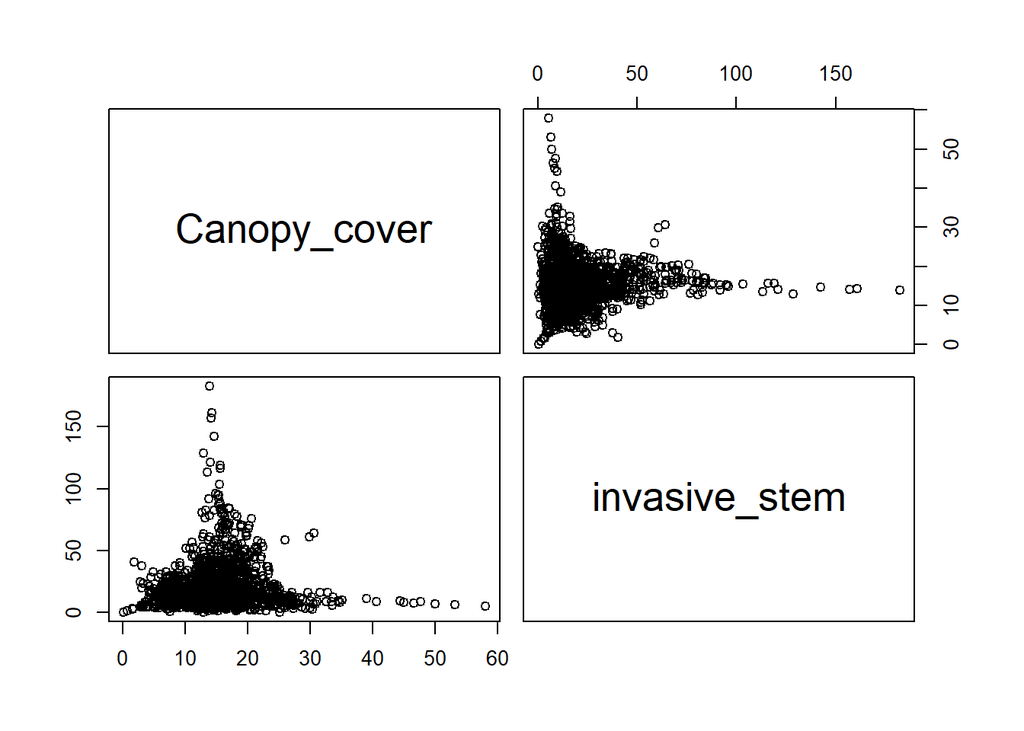

```r
NEC_RSF_df[,c("Canopy_cover", "invasive_stem")] |> pairs()
```

## Compare Used vs Available Distributions

Comparing the distributions of covariates between used and available points helps us understand habitat selection patterns.

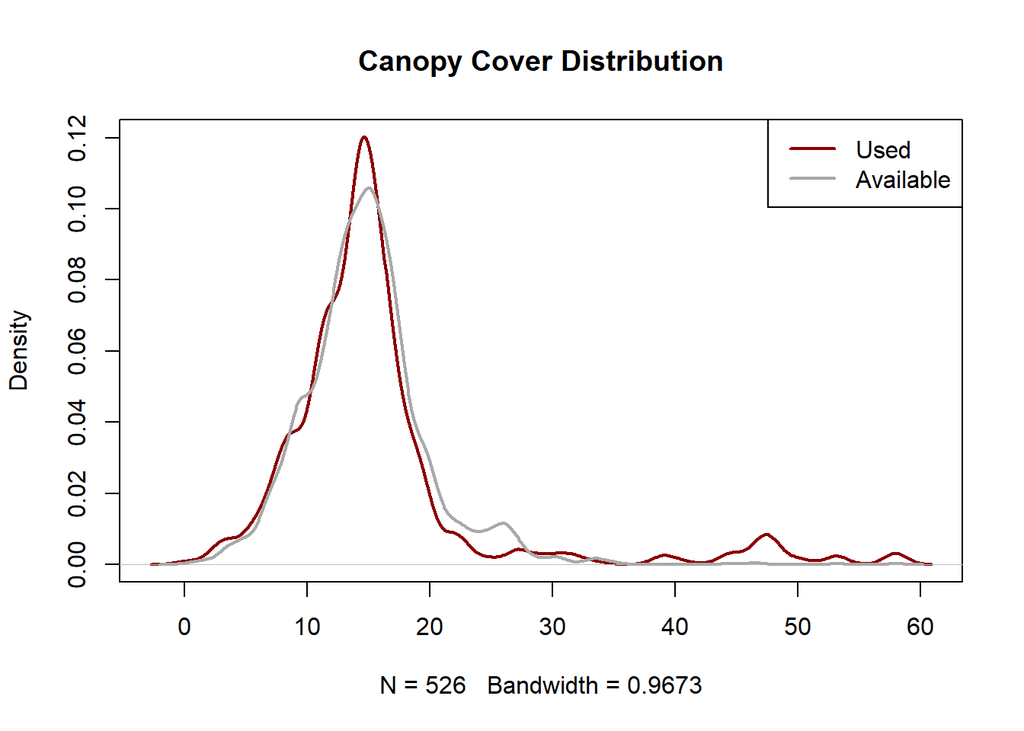

```r
with(NEC_RSF_df, {
  plot(density(Canopy_cover[Used]), col = "darkred", lwd = 2,
       main = "Canopy Cover Distribution")
  lines(density(Canopy_cover[!Used]), col = "darkgrey", lwd = 2)
  legend("topright", legend = c("Used", "Available"),
         col = c("darkred", "darkgrey"), lwd = 2)
})
```

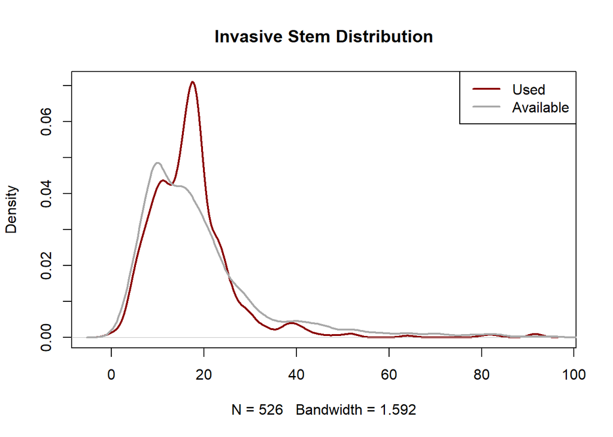

```r
with(NEC_RSF_df, {
  plot(density(invasive_stem[Used]), col = "darkred", lwd = 2,
       main = "Invasive Stem Distribution")
  lines(density(invasive_stem[!Used]), col = "darkgrey", lwd = 2)
  legend("topright", legend = c("Used", "Available"),
         col = c("darkred", "darkgrey"), lwd = 2)
})
```

# Model Fitting and Selection

## Simple Additive Model

We’ll start with a simple additive model:

```r
M1 <- glm(Used ~ Canopy_cover + invasive_stem,
          data = NEC_RSF_df,
          family = "binomial")

summary(M1)
```

```
##
## Call:
## glm(formula = Used ~ Canopy_cover + invasive_stem, family = "binomial",
##     data = NEC_RSF_df)
##
## Coefficients:
##                Estimate Std. Error z value Pr(>|z|)
## (Intercept)   -1.733309   0.142520 -12.162  < 2e-16 ***
## Canopy_cover   0.026866   0.007224   3.719  0.00020 ***
## invasive_stem -0.011364   0.003795  -2.994  0.00275 **
## ---
## Signif. codes:  0 '***' 0.001 '**' 0.01 '*' 0.05 '.' 0.1 ' ' 1
##
## (Dispersion parameter for binomial family taken to be 1)
##
##     Null deviance: 2770.3  on 2960  degrees of freedom
## Residual deviance: 2745.9  on 2958  degrees of freedom
## AIC: 2751.9
##
## Number of Fisher Scoring iterations: 4
```

## Compare Multiple Candidate Models

We can efficiently fit and compare multiple models using lists and `lapply`:

```r
formulae <- list(
  M0 = Used ~ 1,
  Canopy = Used ~ Canopy_cover,
  Invasive = Used ~ invasive_stem,
  CanInv = Used ~ Canopy_cover + invasive_stem,
  CanByInv = Used ~ Canopy_cover * invasive_stem
)

fits <- lapply(formulae, function(f)
  glm(f, data = NEC_RSF_df, family = "binomial"))

ldply(fits, AIC)
```

| .id | V1 |
| --- | --- |
| M0 | 2772.312 |
| Canopy | 2760.123 |
| Invasive | 2763.133 |
| CanInv | 2751.901 |
| CanByInv | 2704.801 |

## Polynomial Models

Biological relationships are often non-linear. Let’s fit models with polynomial terms:

```r
moreformulae <- list(
  C2 = Used ~ poly(Canopy_cover, 2),
  I2 = Used ~ poly(invasive_stem, 2),
  C2I2 = Used ~ poly(Canopy_cover, 2) + poly(invasive_stem, 2)
)

morefits <- lapply(moreformulae, function(f)
  glm(f, data = NEC_RSF_df, family = "binomial"))

ldply(morefits, AIC)
```

| .id | V1 |
| --- | --- |
| C2 | 2710.687 |
| I2 | 2753.895 |
| C2I2 | 2691.675 |

## Automated Model Selection with `dredge`

With multiple covariates and polynomial terms, the number of possible models grows quickly. The `dredge` function from the `MuMIn` package automates model selection:

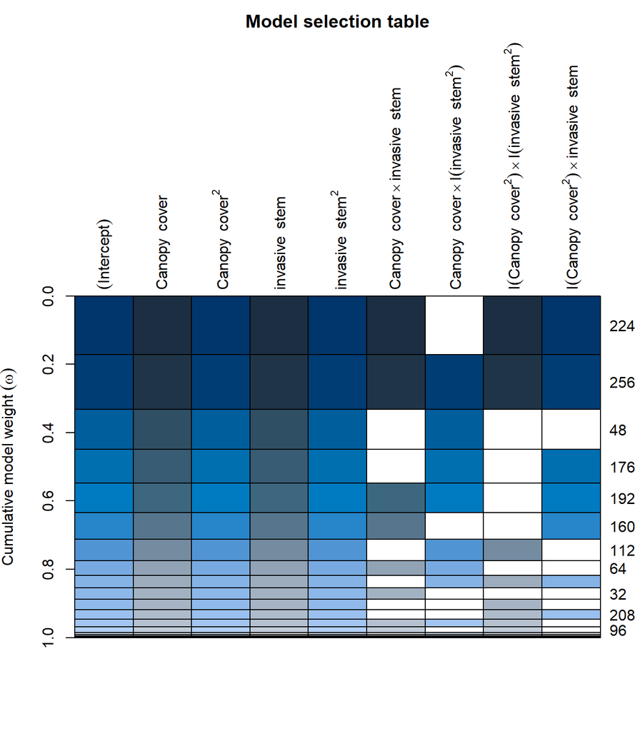

```r
require(MuMIn)

global.model <- glm(Used ~
                      (Canopy_cover + I(Canopy_cover^2)) *
                      (invasive_stem + I(invasive_stem^2)),
                    data = NEC_RSF_df,
                    family = "binomial",
                    na.action = "na.fail")

NEC_dredge <- dredge(global.model)
plot(NEC_dredge)
```

## Final Selected Model

```r
fit <- glm(Used ~ (Canopy_cover + I(Canopy_cover^2)) +
             (invasive_stem + I(invasive_stem^2)) +
             Canopy_cover*invasive_stem,
           family = "binomial",
           data = NEC_RSF_df)

summary(fit)
```

```
##
## Call:
## glm(formula = Used ~ (Canopy_cover + I(Canopy_cover^2)) + (invasive_stem +
##     I(invasive_stem^2)) + Canopy_cover * invasive_stem, family = "binomial",
##     data = NEC_RSF_df)
##
## Coefficients:
##                              Estimate Std. Error z value Pr(>|z|)
## (Intercept)                -2.1097704  0.4075611  -5.177 2.26e-07 ***
## Canopy_cover               -0.0231174  0.0341789  -0.676  0.49881
## I(Canopy_cover^2)           0.0022606  0.0005698   3.967 7.27e-05 ***
## invasive_stem               0.0974739  0.0204508   4.766 1.88e-06 ***
## I(invasive_stem^2)         -0.0006513  0.0002292  -2.841  0.00450 **
## Canopy_cover:invasive_stem -0.0042915  0.0011683  -3.673  0.00024 ***
## ---
## Signif. codes:  0 '***' 0.001 '**' 0.01 '*' 0.05 '.' 0.1 ' ' 1
##
## (Dispersion parameter for binomial family taken to be 1)
##
##     Null deviance: 2770.3  on 2960  degrees of freedom
## Residual deviance: 2667.1  on 2955  degrees of freedom
## AIC: 2679.1
##
## Number of Fisher Scoring iterations: 6
```

# Spatial Predictions

## Create Prediction Raster

We can now predict habitat suitability across the entire study area:

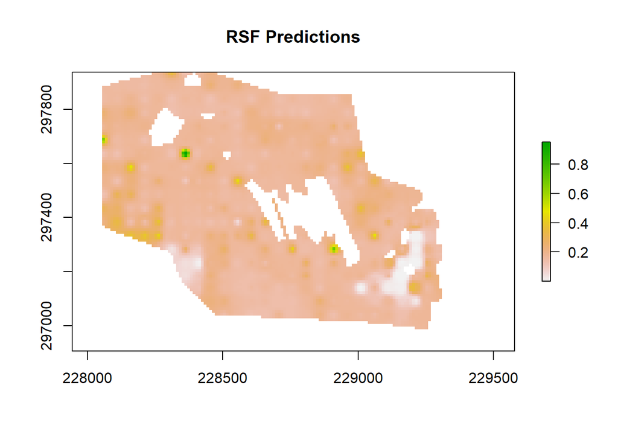

```r
covars_predict <- values(Cranberry_covariates)
RSF_predict <- predict(fit, newdata = data.frame(covars_predict), type = "response")

RSF_raster <- Cranberry_covariates[[1]] * NA
values(RSF_raster) <- RSF_predict

plot(RSF_raster, main = "RSF Predictions")
```

## Classify into Habitat Quality Categories

We can break the continuous predictions into quantile-based categories:

```r
breaks <- quantile(values(RSF_raster), seq(0, 1, length = 11), na.rm = TRUE)
```

Create a discrete version:

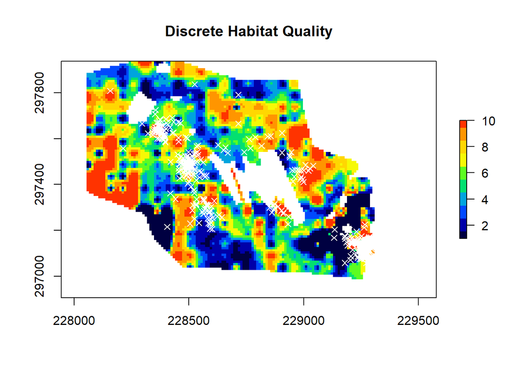

```r
RSF_raster_discrete <- cut(RSF_raster, breaks)
plot(RSF_raster_discrete, col = rich.colors(10),
     main = "Discrete Habitat Quality")
plot(CranNEC_sf, add = TRUE, col = "white", pch = 4)
```

# Visualize Interactions

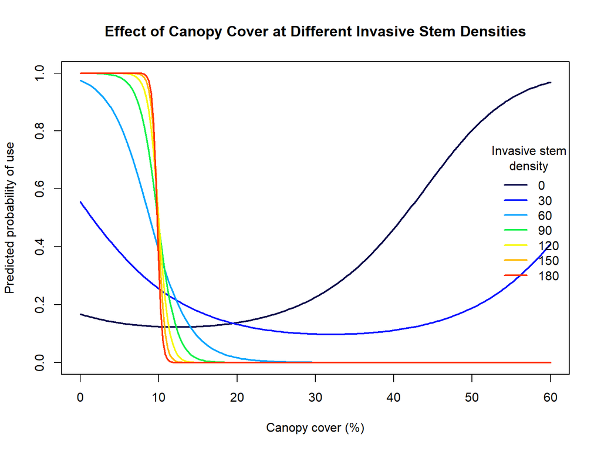

```r
canopy_seq <- seq(0, 60, length.out = 200)
invasive_levels <- seq(0, 180, 30)
colors <- rich.colors(length(invasive_levels))

plot(canopy_seq, canopy_seq, type = "n", ylim = c(0, 1),
     xlab = "Canopy cover (%)",
     ylab = "Predicted probability of use",
     main = "Effect of Canopy Cover at Different Invasive Stem Densities")

for(i in seq_along(invasive_levels)) {
  newdata <- data.frame(Canopy_cover = canopy_seq,
                        invasive_stem = invasive_levels[i])
  pred <- predict(fit, newdata = newdata, type = "response")
  lines(canopy_seq, pred, col = colors[i], lwd = 2)
}

legend("right",
       legend = invasive_levels,
       title = "Invasive stem\ndensity",
       col = colors,
       lwd = 2,
       bty = "n")
```